# Attribute based Networks and Clustering - Does learning from entity attributes lead to greater classification accuracy?

## An analysis into semantic organization by Chiebuka Ohams

### Created: 12/10/2022

1. Introudction and Motivation and Question
2. Data Loading and editing
3. Neural Network Training and Comparison Analysis
4. Conclusion

# 1. Introduction

Artificial Neural Networks have proved themselves to be very powerful tools in performing tasks (namely classification) on raw data. As an example on the ImageNet dataset, modern neural network models have reached 91% Top-1 accuracy for classification (https://paperswithcode.com/sota/image-classification-on-imagenet). However, what these models learn that is enabling them to perform so well is mostly still a mystery.

It's clear that for us human beings, even though we have unique concepts for each type of entity, we still group entities together not only based on obvious taxonomic similarities (for example lions and tigers are both "cats") but also based on entity attributes (dogs and cats both have fur). For example, dogs and cats are more similar than dogs and birds not just because the first pair are taxonomically similar (both mammals), but they are more similar because they share many attributes (and arguably this is the source of the taxonomic distinction). Dogs and Cats both: have 4 legs, have fur, have tails, etc. Though it may seem obvious that these are true of most mammals, when first seeing these animals it's already clear that they are more similar than the pair "dog and bird" despite not knowing what "mammal" means. So although our semantic knowledge may be organized in a symbolic taxonomy as we mature, initially that cannot be the case since we learn from the raw data presented by the world and not through symbolic manipulation representing entities in the world.

Following this line of reasoning, two reasonable question arise.

1. **How do neural networks organize semantic information about concrete nouns?**
2. **Can utilizing attributes lead to higher classification performance?**

This is what this project aims to explore. The organization of concrete nouns in a neural network has been investigated before, however that was in a a symbolic setting (see Motivation section). This project extends that work by looking at semantic organization based on raw images as opposed to symbolic one-hot encoded vectors.

# Motivation

To get an idea of what has just tbeen described above, let's look at an example.

In this example, we're going to be exploring the semantic organization of a very simple neual network. We will look at a few natural language sentences of entities and their atrtibutes (with respect to some relation) and see how the networks entity representations differ among entites by the end of training. Entities are mapped to attributes/properties via predicates relations.

This is a reimplementation of the paper linked here: https://www.nature.com/articles/nrn1076. Note: The idea for the example was reimplemented from the paper, but the code was written by me.

```python
import numpy as np
import torch
from tqdm import tqdm
from nltk.corpus import wordnet as wn
import torch
import torch.nn as nn
import torch.optim as optim
import torchvision
import torchvision.transforms as transforms
import matplotlib.pyplot as plt
import seaborn as sns
from scipy.cluster.hierarchy import dendrogram, linkage
from scipy.stats import chisquare
from sklearn.cluster import KMeans
from sklearn.decomposition import PCA
from collections import defaultdict
```

For this, we will use the entities, relations, and attributes that were used in the paper linked above.

Here we first create the entities, relations, and attributes to be used.

These entities are used since they are easily organized taxonomically, they share a good number of the attributes amongst themselves, and they have attributes that are also unique to them. The relations are there so that entities can be mapped to attributes in an appropriate manner.

```python
# Entities
items = ['pine', 'oak', 'rose', 'daisy', 'robin', 'canary', 'sunfish', 'salmon']
#items_to_index = {items[i]:i for i in range(len(items))}
#index_to_items = {i:items[i] for i in range(len(items))}

# Predicate Relations
relations = ['isa', 'is', 'can', 'has']

# All the attributes used for to describe the entities
isa_attributes = ['living_thing', 'plant', 'animal', 'tree', 'flower', 'bird', 'fish']
is_attributes = ['pretty', 'tall', 'living', 'green', 'red', 'yellow', 'big']
can_attributes = ['grow', 'move', 'swim', 'fly', 'sing', 'bark']
has_attributes = ['petals', 'wings', 'feathers', 'scales', 'gills', 'roots', 'skin', 'leaves']
attributes = isa_attributes + is_attributes + can_attributes + has_attributes
```

This function will then be used to map each of the items in the lists to one-hot encoded vectors, so that we can use the vectors to learn mappings between the entities, relations, and attributes.

```python
def make_vectors(list_of_xs):
    x_to_vectors = {}

    # Create identity matrix size of input
    vectors = np.eye(len(list_of_xs)).astype(np.float32)

    # Map each item in input to unique row from identity matrix
    for index, x in enumerate(list_of_xs):
        x_to_vectors[x] = vectors[index]

    return x_to_vectors
```

We then use the function above to create the one-hot encoded vectors for the entities, relations, and attributes.

```python
items_to_vectors = make_vectors(items)
relations_to_vectors = make_vectors(relations)
attributes_to_vectors = make_vectors(attributes)
```

In order to learn mappings, we have to create propositions that involve the appropriate entity-relation-attribute connections. So to do that I create a list of propositions in natural language which will serve as the training exmaples for the neural network. These propositions are what I gather were used from the taxonomic organization in the paper above.

```python
propositions = [
    'pine isa tree, plant, living_thing',
    'pine is green, big, living',
    'pine has bark, roots',
    'pine can grow',
    'oak isa tree, plant, living_thing',
    'oak is tall, big, living',
    'oak has leaves, bark, roots',
    'oak can grow',
    'rose isa flower, plant, living_thing',
    'rose is red, pretty, living',
    'rose has petals, leaves, roots',
    'rose can grow',
    'daisy isa flower, plant, living_thing',
    'daisy is yellow, pretty, living',
    'daisy has leaves, petals, roots',
    'daisy can grow',
    'robin isa bird, animal, living_thing',
    'robin is red, living',
    'robin has wings, feathers, skin',
    'robin can fly, move, grow',
    'canary isa bird, animal, living_thing',
    'canary is yellow, living',
    'canary has wings, feathers, skin',
    'canary can sing, fly, move, grow',
    'sunfish isa fish, animal, living_thing',
    'sunfish is yellow, living',
    'sunfish has gills, scales, skin',
    'sunfish can swim, move, grow',
    'salmon isa fish, animal, living_thing',
    'salmon is red living',
    'salmon has gills, scales, skin',
    'salmon can swim, move, grow'
]
```

This function takes a list of natural language propositions and returns a list of tuples of the one-hot encoded version of the proposition. Here, we want the output to be of the form ((entity, relation), attribute), so that for the neural network the input is the entity and relation and the output is the attribute. More explicitly, we are leanring a {(entity, relation) -> attribute} mapping. Since this function uses a look up, it does not work with words not already in the lists created above.

```python
def parse_propositions(propositions):
    parsed_propositions = []

    for proposition in propositions:
        # Splits the proposition based on spaces
        proposition_parts = proposition.split()

        # Full attribute vector to be used for each proposition
        targets = np.zeros(len(attributes))

        # Sum the one-hot encoded vectors for the attributes for this proposition
        for part in proposition_parts[2:]:
            targets += attributes_to_vectors[part.replace(',', '')]

        # Get one-hot encoded vector for entity and relation
        item = items_to_vectors[proposition_parts[0]]
        relation = relations_to_vectors[proposition_parts[1]]

        # Package the entity-relation-attribute combo
        parsed_propositions.append(((item, relation), targets))

    return parsed_propositions
```

Now we use the function defined above to actually parse the natural language propositions that we defined earlier.

```python
learning_data = parse_propositions(propositions)
```

Now we begin to actually create the network so that we can analyze how it organizes semantic information.

Here we create the simple artificial neural network that will use the training examples (vector propositions) above to learn representations of the entities based on the relations and constrained by the attributes. The layer design (2 hidden, 1 output) follows the design in the paper above. We keep the architectre simple so as to minimize the number of other influencing factors on the networks organization.

```python
class semantic_network(nn.Module):
    def __init__(self, num_items, num_relations, num_attributes):
        super(semantic_network, self).__init__()

        # Layer representing the entity to internal representation of the network
        self.item_to_rep = nn.Linear(num_items, num_items)

        # Layer used to combine the representation from above with the predicate relation
        self.combine = nn.Linear(num_items + num_relations, num_items + num_relations)

        # Layer used to predict the attributes based on the information above
        self.complete_query = nn.Linear(num_items + num_relations, num_attributes)

    def forward(self, x):
        # Extract the entity and the relation
        item = x[0]
        relation = x[1]

        # Generate the representation
        representation = self.item_to_rep(item)

        # Combine representation and relation
        hidden = self.combine(torch.cat((representation, relation), 0))

        # Predict attributes
        out = self.complete_query(hidden)

        return out, representation
```

We now instatiate the model using information about the number of entities, the number of relations, and the number of attributes. We then set a high number for the number of epochs to ensure that the representations for the entities have a chance to settle into a stable position and are not still changing. We set the learning rate to a standard value that will allow the network to learn fast. We use a Binary Cross Entropy with Logits since we are essentially doing multiclass and multilabel classification. We use Stochastic Gradient Descent so that training proceeds quickly.

```python
model = semantic_network(8, 4, len(attributes))

epochs = 2000
learning_rate = 0.01

lossfunction = nn.BCEWithLogitsLoss()
optimizer = optim.SGD(model.parameters(), lr=learning_rate)
```

```python
for epoch in range (epochs):
    total_loss = 0
    #train loop
    for (item, relation), attribute in learning_data:
        # Get example for training data list and convert vectors into torch tensors
        (item, relation), attribute = (torch.from_numpy(item), torch.from_numpy(relation)), torch.from_numpy(attribute)

        #forward
        logits, representation = model((item, relation))

        #loss
        loss = lossfunction(logits, attribute)
        total_loss += loss.item()

        #backward
        loss.backward()

        #update
        optimizer.step()
        optimizer.zero_grad()

    # Print the training progress to ensure learning is stable
    if epoch % 200 == 0:
        print(f"Loss: {total_loss/len(learning_data)}")
        print()
```

```
Loss: 0.6858891422189116

Loss: 0.27160612209575313

Loss: 0.23286252082263154

Loss: 0.18646512094502604

Loss: 0.15442639111435189

Loss: 0.13397459692818564

Loss: 0.11428848456262132

Loss: 0.09346222104933792

Loss: 0.07867361797449082

Loss: 0.06964602845003753
```

Now that training is complete, we look at the intermediate representations of the different entities to determine how the representations differ among the different entities. We first use linkage dendrogram to determine the similarties of the representations based on euclidean distance, then we look at the raw representation to get a qualitative feel on how they differ. The linkage dendrogram will give is a sense of how the representations cluster taxononically, and the raw representations will may give us insight into what the different dimensions of the representation mean.

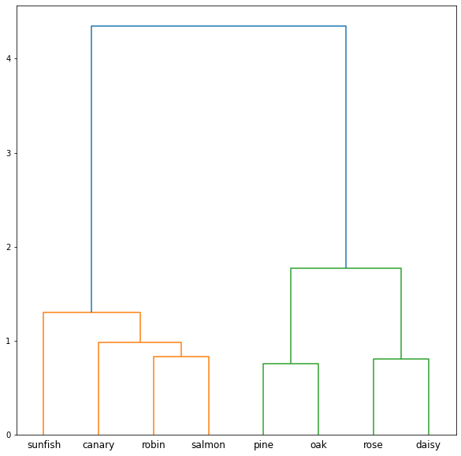

```python
# torch no grad since we are not training and thus do not need gradients
with torch.no_grad():
    curr_progress = {}

    # Pass the one-hot encoded vector through to the first layer of the model
    #  defined above to get the entity representation
    for item in items:
        curr_progress[item] = model.item_to_rep(torch.from_numpy(items_to_vectors[item])).numpy()

# Create the linkage dendrogram to a get a sense of the taxonomic organization based on euclidean distance
linkage_data = linkage(list(curr_progress.values()), method='ward', metric='euclidean')
plt.figure(figsize=(10, 10))
dendrogram(linkage_data, labels=list(curr_progress.keys()))
print()
```

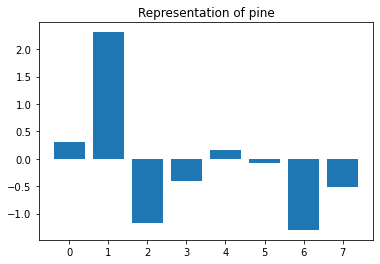

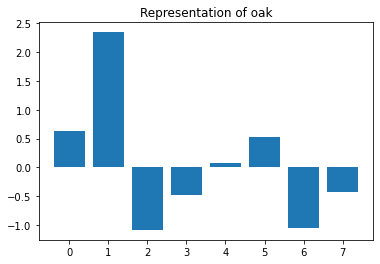

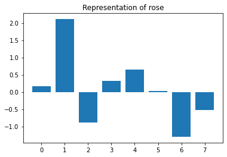

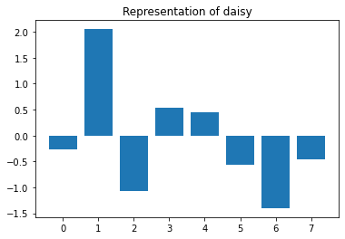

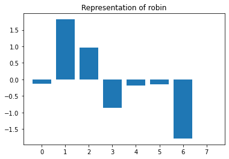

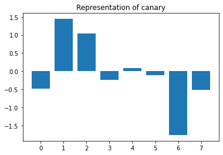

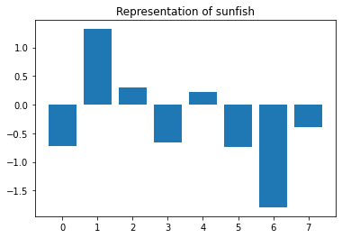

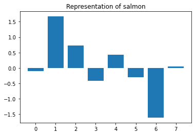

```python
# Create barplots for each entity representation
for item, representation in curr_progress.items():
    plt.bar([i for i in range(len(items))], curr_progress[item])
    plt.title(f"Representation of {item}")
    plt.show()
```

However, as mentioned above we as humans clearly do not learn based on purely symbolic inputs as done above. So, moving forward we will be looking at the use of raw images as input.

# Questions

To reiterate I will be augmenting an image dataset, so that I can create a network that learns based on attributes of the image as opposed to simply the using the single classification label. In doing this we will be able to get a sense of whether augmenting a dataset with handcrafted intermediate features will boost the learning signal in classification tasks. This also may allow for the creation of algorithms that perform in more human like ways since we are restricting the ways that the classification algorithms can learn by introducing inductive biases.

Questions:

- Can utilizing attributes lead to higher classification performance? / Does augmenting a dataset with handcrated learning signals boost classification accuracy?
- In what ways do the neural representations of the inputs cluster between classes?
- In what ways does a neural classifier predict when learning from properties?

# Data Curation/Augmentation/Exploration

In this analysis we will be using the CIFAR10 dataset. The CIFAR-10 dataset is a dataset consisting of 60000 32x32 images distributed over 10 classes with 6000 images per class. I am using this dataset because it has a small number of classes making it reasonable to create natural language propositions for each class, and it will be reasonable to visualize and statiscally test the differences between the different classes. This dataset also has an even distribution of classes among the images meaning no particular class will be biased over others. CIFAR-10: https://www.cs.toronto.edu/~kriz/cifar.html

To access the dataset, I will be using the torchvision.datasets library. I then transform the images into normalized tensors with range [-1, 1] so that it is easier for the network to learn (by stabilizing the gradient, preventing it from growing it too large).

```python
# Create image transforms
transform = transforms.Compose(
    [transforms.ToTensor(),
     transforms.Normalize((0.5, 0.5, 0.5), (0.5, 0.5, 0.5))])

# Large batch size - just for visualizing some sample images
batch_size = 64

# Get the training data and create the loader
trainset = torchvision.datasets.CIFAR10(root='./data', train=True,
                                        download=True, transform=transform)
trainloader = torch.utils.data.DataLoader(trainset, batch_size=batch_size,
                                          shuffle=False, num_workers=1)
```

```
Files already downloaded and verified
```

We then explicitly list the entity classes, relations, and attributes that will be used to map the classes to attributes by relations. These lists are clearly not extensive, but it is not meant to be. These lists of attributes are meant to capture important similarities between the entities named, while also noting important differences between them as well. This will allow similar classes to hopefull have similar representations, while also allowing the network to distinguish between them by using their unique attributes.

Below that, using the entities, relations, and attributes I create a list of propositions that are essentially a map between the classes/relations and attributes as exaplined before. During training these propositions will be used with the image to train the network.

```python
items = ['plane', 'car', 'bird', 'cat', 'deer', 'dog', 'frog', 'horse', 'ship', 'truck']
#items_to_index = {items[i]:i for i in range(len(items))}
index_to_items = {i:items[i] for i in range(len(items))}

relations = ['is', 'can', 'has']

#isa_attributes = ['living_thing', 'non_living_thing', 'vehicle', 'house_pet']
is_attributes = [ 'living', 'nonliving', 'big', 'fast', 'domesticated', 'wild']
can_attributes = ['grow', 'drive', 'swim', 'fly', 'sing', 'bark', 'meow', 'run']
has_attributes = ['wings', 'wheels', 'doors', 'steering_wheel', 'fur', 'claws', 'hooves',
                  'antlers', 'slimy_skin', 'feathers', 'mane', 'rudder']
attributes =  is_attributes + can_attributes + has_attributes
```

```python
propositions = [
    'plane is big, fast, nonliving',
    'plane can fly',
    'plane has wings, wheels',
    'car is fast, nonliving',
    'car can drive',
    'car has doors, wheels, steering_wheel',
    'bird is living, wild',
    'bird can grow, fly, sing',
    'bird has wings, feathers',
    'cat is living, domesticated',
    'cat can grow, meow, run, swim',
    'cat has fur, claws',
    'deer is living, wild',
    'deer can grow, run, swim',
    'deer has fur, hooves, antlers',
    'dog is living, domesticated',
    'dog can grow, run, swim, bark',
    'dog has fur, claws',
    'frog is living, wild',
    'frog can grow, swim',
    'frog has slimy_skin',
    'horse is living, fast, wild, domesticated',
    'horse can grow, run, swim',
    'horse has fur, hooves, mane',
    'ship is big, nonliving',
    'ship can swim',
    'ship has rudder',
    'truck is nonliving',
    'truck can drive',
    'truck has wheels, doors, steering_wheel'
]
```

In this part, we don't use the 'isa' relation because it involves knowledge that is not usually obtained from pure observation, but rather from a mix of knowledge from other sources (people, reading, etc). Additionally, for our purposes, the 'isa' relation is too explicit of a signal in terms of how to organize the entities the network will be trained on. The network could simply zone in on that relation and use the similarities between the 'isa' relation attributes to generate the taxonomy, but we want that to be a result and not a given, so we don't include it here.

We then visualize some of the images to get a sense of the data we are working with.

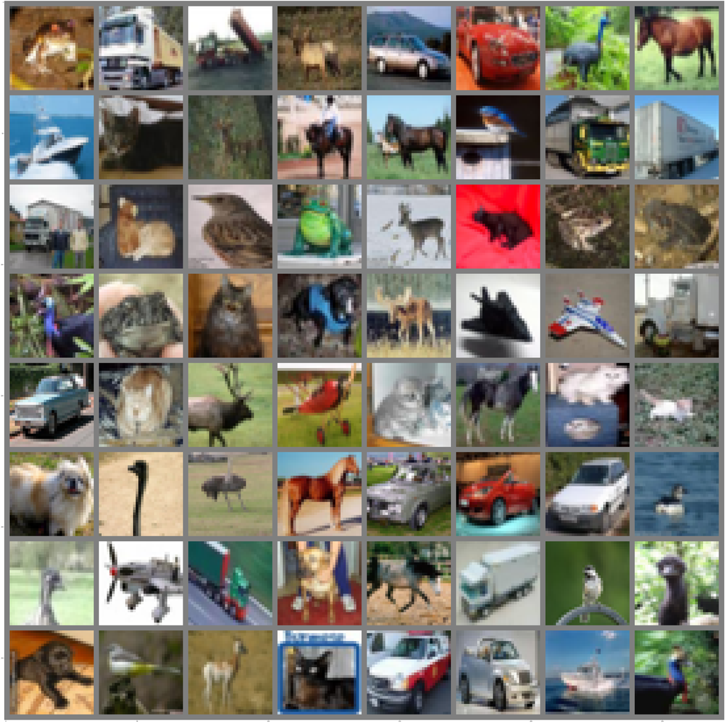

```
frog  truck truck deer  car   car   bird  horse ship  cat   deer  horse horse bird  truck truck truck cat   bird  frog  deer  cat   frog  frog  bird  frog  cat   dog   deer  plane plane truck car   cat   deer  plane cat   horse cat   cat   dog   bird  bird  horse car   car   car   bird  bird  plane …
```

```python
# *** Code borrowed from https://pytorch.org/tutorials/beginner/blitz/cifar10_tutorial.html ***

def imshow(img):
    # unnormalize the image
    img = img / 2 + 0.5
    npimg = img.numpy()
    # increase size of plit and plot the image
    plt.figure(figsize = (100, 100))
    plt.imshow(np.transpose(npimg, (1, 2, 0)))
    plt.show()


# get some random training images
dataiter = iter(trainloader)
images, labels = next(dataiter)

# display the images
imshow(torchvision.utils.make_grid(images))

# print labels
print(' '.join(f'{items[labels[j]]:5s}' for j in range(batch_size)))
```

An initial investigation we can do is to look at the similarity of the images based on euclidean distance to determine if augmenting the data even initially makes sense. If images with more similar classes are already numerically similar then there would be no point in introducing more signal. To perform a quick comparison we will look use some of the images above.

We will compare (1) two horse images, (2) a horse with a airplane image and (3) a horse with a bird image.

```python
# Choosing two horse images from above and calculating the image distance
horse1 = images[7].reshape(-1, 3*32*32)
horse2 = images[11].reshape(-1, 3*32*32)
print(f"Similarity between horse images: {((horse1-horse2)**2).sum()}")

# Choosing a airplane image from above and calculating distance with one horse image
airplane = images[35].reshape(-1, 3*32*32)
print(f"Similarity between horse and airplane images: {((horse1-airplane)**2).sum()}")

# Choosing a bird image from above and calculating distance with one horse image
bird = images[54].reshape(-1, 3*32*32)
print(f"Similarity between horse and bird images: {((horse1-bird)**2).sum()}")
```

```
Similarity between horse images: 1674.8489990234375
Similarity between horse and airplane images: 1217.78125
Similarity between horse and bird images: 1267.9169921875
```

As you can see using an image distance metric it's clear that, numerical similarity between images is not enough to learn the kinds of taxonomic similarities that were discussed above. Based on euclidean distance the airplane and horse images were closest, then the bird and horse images, and lastly the horse and horse images. What we would have wanted was (1) horse-horse (2) horse-bird (3) horse-airplane, since based on properties that ranking reflects the pairs of entities that are most similar.

## Set up the Artificial Neural Network and Train it

Next, we get right to creating the network that will learn based on attributes as opposed to learning based on the class category. To do this we will use pytorch like above. Here we use a convolutional neural network as opposed to simple network, so that we can take advantage of the local properties present in the images. Simple networks destroy information about that locality of features since they flatten everything. By using a convolutional network, we may be able to map feature patterns in the images to the attributes.

In terms of architecture, We use a simple architecture (Conv-relu-maxpool-conv-relu-maxpool-conv-fully_connected network), this is so we can take advantage of the power of the convolutional layers while keeping the amount of extra influences that could cause the network to perform well (that are not strictly due to attributes) to a minimum.

```python
class image_network(nn.Module):
    def __init__(self, num_relations, num_attributes):
        super(image_network, self).__init__()

        # Sequence of transformations to create image representation
        self.image_to_rep = nn.Sequential(
            nn.Conv2d(3, 8, 3),
            nn.ReLU(),
            nn.MaxPool2d(2, 2),
            nn.Conv2d(8, 16, 3),
            nn.ReLU(),
            nn.MaxPool2d(2, 2),
            nn.Conv2d(16, 32, 3),
            nn.Flatten(),
            nn.Linear(512, 64)
        )

        # Layer to ombine the image representation with the relation
        self.combine = nn.Linear(64 + num_relations, 64 + num_relations)

        # Predict the attributes based on the image+relation combo
        self.complete_query = nn.Linear(64 + num_relations, num_attributes)

    def forward(self, img, relation):
        # Create the image representation
        representation = self.image_to_rep(img)

        # Combine the image and relation
        hidden = self.combine(torch.cat((representation, torch.unsqueeze(relation, 0)), 1))

        # Make attributes prediction
        out = self.complete_query(hidden)

        return out, representation
```

We now reload the data so that we can easily map images and their classes from the CIFAR-10 dataset to the natural language propositions that I created above. We will only be loading one example at a time so that this mapping is simple. We use the same transformations as above.

After that, using the same method as above, we parse the natural language propositions into one-hot encoded vectors so we can use them to train the neural network.

```python
# Create image transforms
transform = transforms.Compose(
    [transforms.ToTensor(),
     transforms.Normalize((0.5, 0.5, 0.5), (0.5, 0.5, 0.5))])

# Small batch size so that we can load one example at a time - makes mapping easier
batch_size = 1

# Get the training/test data and create the loader
trainset = torchvision.datasets.CIFAR10(root='./data', train=True,
                                        download=True, transform=transform)
trainloader = torch.utils.data.DataLoader(trainset, batch_size=batch_size,
                                          shuffle=True, num_workers=1)

testset = torchvision.datasets.CIFAR10(root='./data', train=False,
                                       download=True, transform=transform)
testloader = torch.utils.data.DataLoader(testset, batch_size=batch_size,
                                         shuffle=True, num_workers=1)
```

```
Files already downloaded and verified
Files already downloaded and verified
```

```python
items_to_vectors = make_vectors(items)
relations_to_vectors = make_vectors(relations)
attributes_to_vectors = make_vectors(attributes)
```

```python
image_propositions = parse_propositions(propositions)
```

Here we instantiate the model, set the learning parameters, loss function, and the optimizer. We use a low number of epochs because based on earlier testing it seems that the representations settle after just one 1 epoch. The loss function is Binary Cross Entropy with Logits Loss since we are doing a mix of multiclass and multilabel classification.

We also log the differentiation dynamics. Now we are not only going to look at the final cluster of representations, but we are going to look at all the intermediate clsutering of representations while the training is going on. This will give us a sense of how the network chooses to group/differtiate between different entities a it learns from the attributes.

```python
model = image_network(3, len(attributes))

epochs = 3
learning_rate = 0.01

lossfunction = nn.BCEWithLogitsLoss()
optimizer = optim.SGD(model.parameters(), lr=learning_rate)
```

```python
# for logging differentiation dynamics
differentiation = []

for epoch in range (epochs):
    total_loss = 0
    #train loop
    for num, (image, label) in enumerate(tqdm(trainloader)):

        for i in range(3):

            #forward
            relation = torch.from_numpy(image_propositions[label*3+i][0][1])
            attribute = torch.from_numpy(image_propositions[label*3+i][1])
            logits, representation = model(image, relation)

            #loss
            loss = lossfunction(logits, torch.unsqueeze(attribute, 0))
            total_loss += loss.item()

            #backward
            loss.backward()

            #update
            optimizer.step()
            optimizer.zero_grad()

        if epoch == 0:
            if (num == 0 or num == 10 or num == 50 or num == 200
            or num == 10000 or num == len(trainloader)-1):
                # Here we track the differentiation progress of the network
                with torch.no_grad():
                    curr_progress = defaultdict(int)
                    # Iterate through test loader and calculate what the average entity representations are
                    for image, label in testloader:
                        curr_progress[label.item()] += model.image_to_rep(image).numpy()

                    # Rescale by the number of images for that entity
                    for label, representation in curr_progress.items():
                        curr_progress[label] = representation.flatten() / 1000

                    # Add current average representation to differentiation progress
                    differentiation.append(curr_progress)


    print(f"Loss: {total_loss/(len(trainloader))}")
    print()
```

```
Loss: 0.429611420356102
```

```
Loss: 0.302673625728357
```

```
Loss: 0.2765738236544832
```

## Semantic Organization and Clustering

Now that we have finished training based on the attributes, we plot the linkage dendrograms of the representations during training to get a sense of the differentiation dynamics of the network. Also as done before we plot the raw representations, not for insight, but just to get a feel for how they look.

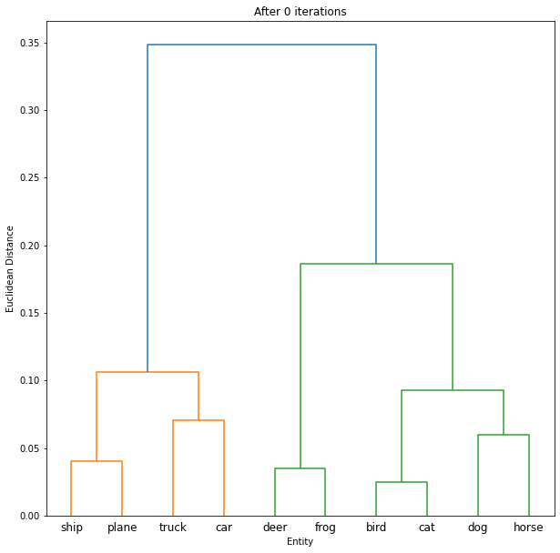

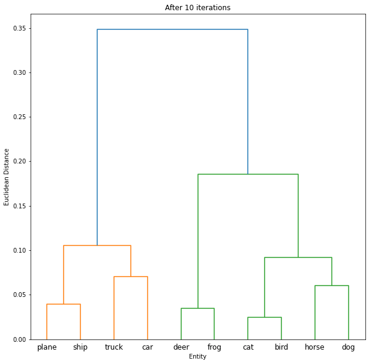

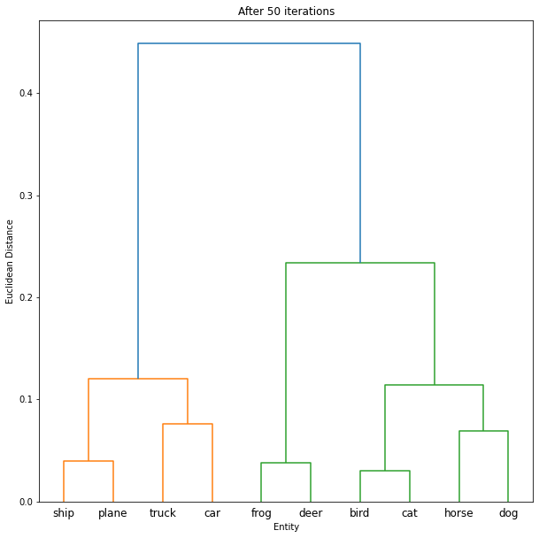

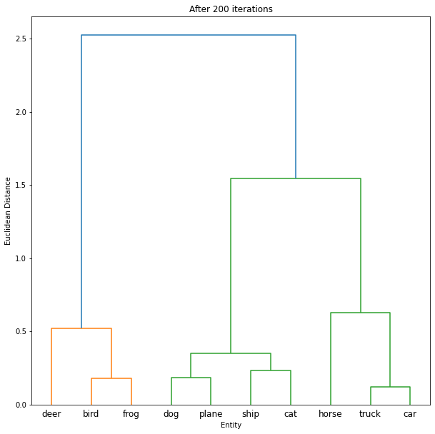

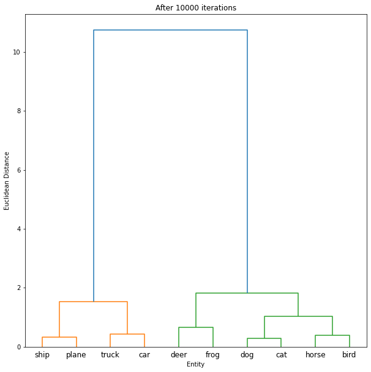

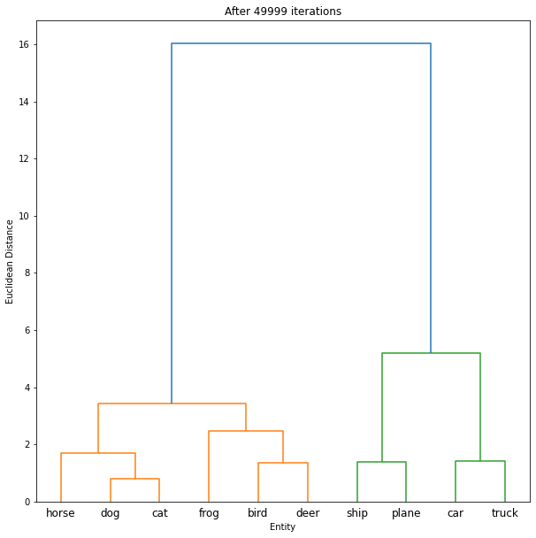

```python
num_iterations = [0, 10, 50, 200, 10000, 49999]

for index, iteration in enumerate(differentiation):
    # Create the linkage dendrogram to a get a sense of the taxonomic organization based on euclidean distance
    linkage_data = linkage(list(iteration.values()), method='ward', metric='euclidean')
    plt.figure(figsize=(10, 10))
    dendrogram(linkage_data, labels=[index_to_items[index] for index in iteration.keys()])
    plt.xlabel("Entity")
    plt.ylabel("Euclidean Distance")
    plt.title(f"After {num_iterations[index]} iterations")
    plt.show()
```

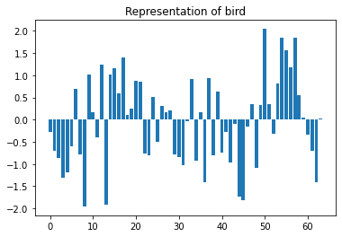

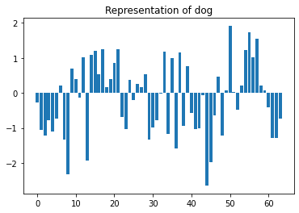

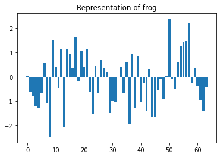

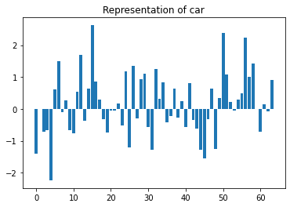

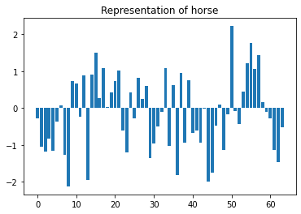

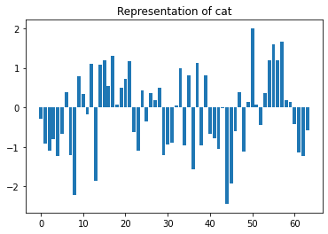

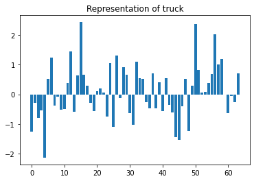

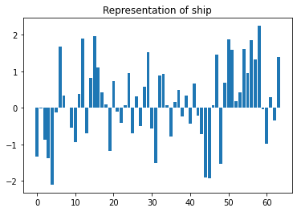

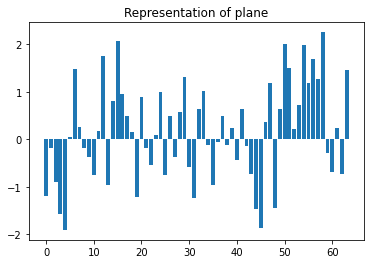

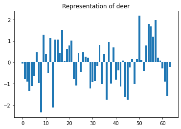

```python
for item, representation in curr_progress.items():
    plt.bar([i for i in range(64)], curr_progress[item])
    plt.title(f"Representation of {index_to_items[item]}")
    plt.show()
```

From the clustering analysis it's clear to see that our intuition about how the representations would cluster is correct. We believed that the neural network algorithm would learn to cluster images that are taxonomically similar, this seems to be the case. The vehicles are clustered together and the animals are clustered together. Within vehicles car and truck are closer, and within animals cat and dog are close. The only aspect of the clustering that does not match our intuition is that deer is very similar to bird and frog as opposed to horse, dog, or cat. This not only does not match our intution about how the classes should cluster, but it is also unexpected based on the attributes that deer has. Deer has attributes that are most similar to horse, so we expected that it would cluster closely with horse. It's unclear as to why this is happening.

Additionally, it looks like the representations for each of the classes also reflect the idea of taxonomic similarity. This way of visualizing the representations is much more opaque than the clustering analysis so we will not discuss it here any further.

To push this point even further we wil now use a combination of PCA and K-means clustering to visually see the clusters. We utilize PCA so that we can reduce the dimensionality of the representations and actually visualize there relationships.

We will use a k-value of 5, which will stand for pairs of entities.

If our intuitions are correct we should be able to clearly see separations between the entities in each of the clusters. This would provide more support for the idea that our network is taxonomically clustering based on attribute.

```python
# Get the representations of the final run of the training loop
data = list(differentiation[-1].values())

# Reduce the dimensionality of the data using PCA
reduced_data = PCA(n_components=2).fit_transform(data)
print(f"PCA reduced (scaled up) representations: \n{reduced_data}")

# Use k-means clustering to see how the representations cluster
kmeans = KMeans(init="k-means++", n_clusters=5, n_init=10)
kmeans.fit(reduced_data)
```

```
PCA reduced (scaled up) representations:
[[-1.81859927 -1.03727101]
 [-3.25215951 -0.04470688]
 [-3.53668439  0.62069349]
 [ 4.77811927  1.94857753]
 [-3.01995545  0.49583961]
 [-2.87306492  0.14492114]
 [ 3.48780225  1.90728007]
 [ 4.91792194 -1.51302127]
 [ 4.37236814 -1.90521778]
 [-3.05574805 -0.61709491]]
```

```
KMeans(n_clusters=5, n_init=10)
```

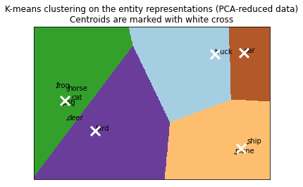

```python
# Code in part borrowed from: https://scikit-learn.org/stable/auto_examples/cluster/plot_kmeans_digits.html
#                     #sphx-glr-auto-examples-cluster-plot-kmeans-digits-py

# Step size of the mesh. Decrease to increase the quality of the VQ.
h = 0.02  # point in the mesh [x_min, x_max]x[y_min, y_max].

# Plot the decision boundary. For that, we will assign a color to each
x_min, x_max = reduced_data[:, 0].min() - 1, reduced_data[:, 0].max() + 1
y_min, y_max = reduced_data[:, 1].min() - 1, reduced_data[:, 1].max() + 1
xx, yy = np.meshgrid(np.arange(x_min, x_max, h), np.arange(y_min, y_max, h))

# Obtain labels for each point in mesh. Use last trained model.
Z = kmeans.predict(np.c_[xx.ravel(), yy.ravel()])

# Put the result into a color plot
Z = Z.reshape(xx.shape)
plt.figure(1)
plt.clf()
plt.imshow(
    Z,
    interpolation="nearest",
    extent=(xx.min(), xx.max(), yy.min(), yy.max()),
    cmap=plt.cm.Paired,
    aspect="auto",
    origin="lower",
)

plt.plot(reduced_data[:, 0], reduced_data[:, 1], "k.", markersize=2)

# plot the labels for each entity
for i, label in enumerate(differentiation[-1].keys()):
    plt.annotate(index_to_items[label], (reduced_data[:, 0][i], reduced_data[:, 1][i]))

# Plot the centroids as a white X
centroids = kmeans.cluster_centers_
plt.scatter(
    centroids[:, 0],
    centroids[:, 1],
    marker="x",
    s=169,
    linewidths=3,
    color="w",
    zorder=10,
)
plt.title(
    "K-means clustering on the entity representations (PCA-reduced data)\n"
    "Centroids are marked with white cross"
)

plt.xlim(x_min, x_max)
plt.ylim(y_min, y_max)
plt.xticks(())
plt.yticks(())
plt.show()
```